# Analisis Pengaruh Keterlibatan Aktor Terhadap Frekuensi Rental Film pada Database Sakila

Alyssa Divania | M0725059 | kelas D

2026-05-20

# 1 Deskripsi Insight

Penelitian ini bertujuan untuk menganalisis apakah aktor yang terlibat dalam lebih banyak film memiliki pengaruh terhadap peningkatan frekuensi rental film pada database **Sakila** — database sampel resmi MySQL yang merepresentasikan sistem manajemen penyewaan film.

> *Apakah aktor yang membintangi lebih banyak film akan menghasilkan jumlah transaksi rental yang lebih tinggi?*

# 2 Connect Data Data SQL ke R

```r
library(DBI)
library(odbc)

con1 <- dbConnect(odbc(),
                  Driver   = "MySQL ODBC 8.0 ANSI Driver",
                  Server   = "127.0.0.1",
                  UID      = "root",
                  PWD      = "Shafidiva23",
                  Port     = 3306,
                  Database = "sakila")
```

## 2.1 Sumber Data

| Tabel | Keterangan |
| --- | --- |
| `actor` | Data identitas aktor |
| `film_actor` | Relasi aktor dan film |
| `film` | Data detail film |
| `inventory` | Stok fisik film |
| `rental` | Transaksi penyewaan film |

## 2.2 Variabel Penelitian

- **`total_films`** — jumlah film unik yang dibintangi seorang aktor
- **`total_rentals`** — jumlah total transaksi rental dari film yang dibintangi aktor

# 3 Query SQL

```sql
SELECT
  a.actor_id,
  CONCAT(a.first_name, ' ', a.last_name) AS actor_name,
  COUNT(DISTINCT fa.film_id) AS total_films,
  COUNT(r.rental_id) AS total_rentals
FROM actor a
  JOIN film_actor fa ON a.actor_id = fa.actor_id
  JOIN film f ON fa.film_id = f.film_id
  JOIN inventory i ON f.film_id = i.film_id
  JOIN rental r ON i.inventory_id = r.inventory_id
GROUP BY a.actor_id, actor_name
ORDER BY total_rentals DESC;
```

**Alur relasi tabel:** `actor` → `film_actor` → `film` → `inventory` → `rental`

# 4 Import Library dan Dataset

```r
library(ggplot2)
library(dplyr)
data <- read.csv("actor_rental.csv")
head(data)
```

```
##   actor_id         actor_name total_films total_rentals
## 1      107     GINA DEGENERES          42           753
## 2      181     MATTHEW CARREY          37           678
## 3      198        MARY KEITEL          40           674
## 4      144 ANGELA WITHERSPOON          35           654
## 5      102        WALTER TORN          39           640
## 6       60        HENRY BERRY          35           612
```

# 5 Visualisasi

## 5.1 Top 10 Aktor dengan Film Terbanyak

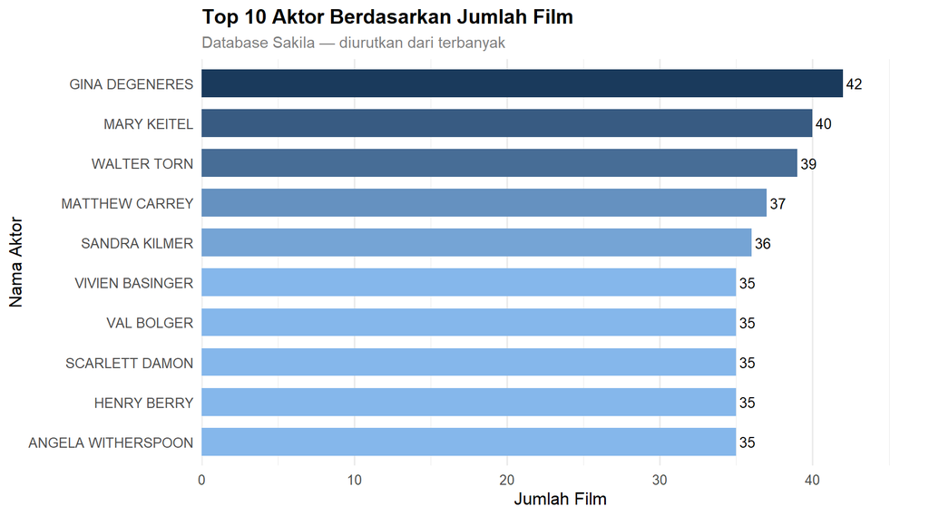

```r
top_actor <- data %>%
  arrange(desc(total_films)) %>%
  slice_head(n = 10)

ggplot(top_actor,
       aes(x = reorder(actor_name, total_films),
           y = total_films,
           fill = total_films)) +
  geom_bar(stat = "identity", show.legend = FALSE, width = 0.7) +
  geom_text(aes(label = total_films), hjust = -0.2, size = 3.5) +
  scale_fill_gradient(low = "#85B7EB", high = "#1a3a5c") +
  coord_flip() +
  scale_y_continuous(expand = expansion(c(0, 0.12))) +
  labs(
    title    = "Top 10 Aktor Berdasarkan Jumlah Film",
    subtitle = "Database Sakila — diurutkan dari terbanyak",
    x = "Nama Aktor",
    y = "Jumlah Film"
  ) +
  theme_minimal(base_size = 12) +
  theme(
    plot.title             = element_text(face = "bold", size = 14),
    plot.subtitle          = element_text(color = "gray50", size = 11),
    panel.grid.major.y     = element_blank()
  )
```

Visualisasi menunjukkan 10 aktor dengan keterlibatan film terbanyak dalam database Sakila. Aktor-aktor ini membintangi jauh lebih banyak film dibanding rata-rata, yang mengindikasikan dominasi sebagian kecil aktor dalam katalog film.

## 5.2 Hubungan Total Film dan Total Rental

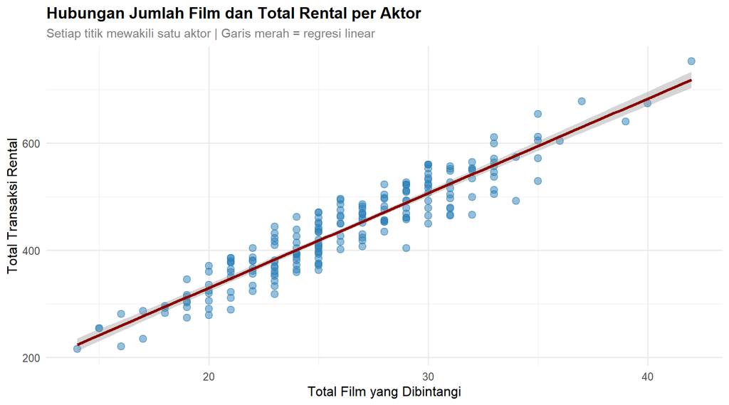

```r
ggplot(data, aes(x = total_films, y = total_rentals)) +
  geom_point(color = "#2c7fb8", alpha = 0.5, size = 2.8) +
  geom_smooth(method = "lm", color = "#8b0000",
              se = TRUE, linewidth = 1.2) +
  labs(
    title    = "Hubungan Jumlah Film dan Total Rental per Aktor",
    subtitle = "Setiap titik mewakili satu aktor | Garis merah = regresi linear",
    x = "Total Film yang Dibintangi",
    y = "Total Transaksi Rental"
  ) +
  theme_minimal(base_size = 12) +
  theme(
    plot.title    = element_text(face = "bold", size = 14),
    plot.subtitle = element_text(color = "gray50", size = 11)
  )
```

# 6 Analisis Regresi Linear

```r
model <- lm(total_rentals ~ total_films, data = data)
summary(model)
```

```
##
## Call:
## lm(formula = total_rentals ~ total_films, data = data)
##
## Residuals:
##     Min      1Q  Median      3Q     Max
## -84.980 -22.838   1.475  25.479  61.442
##
## Coefficients:
##             Estimate Std. Error t value Pr(>|t|)
## (Intercept) -22.8569    12.2208   -1.87   0.0629 .
## total_films  17.6423     0.4577   38.54   <2e-16 ***
## ---
## Signif. codes:  0 '***' 0.001 '**' 0.01 '*' 0.05 '.' 0.1 ' ' 1
##
## Residual standard error: 32.26 on 198 degrees of freedom
## Multiple R-squared:  0.8824, Adjusted R-squared:  0.8818
## F-statistic:  1486 on 1 and 198 DF,  p-value: < 2.2e-16
```

## 6.1 Persamaan Model

$$\hat{Y} = -22{,}86 + 17{,}64 \cdot
X$$

- $\hat{Y}$ = prediksi total rental
- $X$ = jumlah film yang dibintangi
- $-22{,}86$ = intercept
- $17{,}64$ = koefisien regresi

# 7 Interpretasi Hasil

## 7.1 Koefisien Regresi

Koefisien regresi sebesar **17,64** menunjukkan bahwa setiap penambahan **1 film** yang dibintangi aktor akan meningkatkan total rental sebesar sekitar **17 transaksi**.

Artinya, *semakin banyak film yang dibintangi seorang aktor, semakin besar pula peluang film tersebut untuk disewa oleh pelanggan*.

## 7.2 Signifikansi Statistik

Nilai **p-value < 0,05** menunjukkan bahwa variabel `total_films` berpengaruh signifikan terhadap `total_rentals`.

Artinya, jumlah film yang dibintangi aktor memang memiliki hubungan yang nyata terhadap jumlah transaksi rental dalam database Sakila.

## 7.3 Koefisien Determinasi (R²)

Nilai **R² sebesar 88,24%** menunjukkan bahwa model mampu menjelaskan 88,24% variasi jumlah rental berdasarkan jumlah film yang dibintangi aktor.

Sedangkan sisanya sebesar 11,76% dapat dipengaruhi oleh faktor lain, seperti genre film, rating film, atau preferensi pelanggan.

**Kesimpulan**

Berdasarkan hasil visualisasi dan regresi linear, jumlah film yang dibintangi aktor memiliki **pengaruh positif** terhadap total rental film.

Semakin banyak film yang dibintangi seorang aktor, maka semakin tinggi pula potensi jumlah rental yang dihasilkan.

Hal ini dibuktikan dengan nilai p-value yang signifikan serta nilai R² sebesar 88,24% yang menunjukkan model memiliki kemampuan prediksi yang baik. Meski demikian, perlu dipertimbangkan bahwa masih ada faktor lain di luar model yang mungkin turut memengaruhi frekuensi rental.